# Movie Recommendation

Shan Wang

01 March, 2020

# 1 Loading and Cleaning the Data File

Let us first read the data set from the file. This time we will work with a text file.

```r
movies = read.table("Movies.txt", header = FALSE, sep = "|", quote = "")
str(movies)
```

```
## 'data.frame':    1682 obs. of  24 variables:
##  $ V1 : int  1 2 3 4 5 6 7 8 9 10 ...
##  $ V2 : Factor w/ 1664 levels "'Til There Was You (1997)",..: 1525 618 555 594 344 1318 1545 111 391 1240 ...
##  $ V3 : Factor w/ 241 levels "","01-Aug-1997",..: 71 71 71 71 71 71 71 71 71 182 ...
##  $ V4 : logi  NA NA NA NA NA NA ...
##  $ V5 : Factor w/ 1661 levels "","http://us.imdb.com/M/title-exact/Independence%20(1997)",..: 1431 565 505 543 310 1661 1453 103 357 1183 ...
##  $ V6 : int  0 0 0 0 0 0 0 0 0 0 ...
##  $ V7 : int  0 1 0 1 0 0 0 0 0 0 ...
##  $ V8 : int  0 1 0 0 0 0 0 0 0 0 ...
##  $ V9 : int  1 0 0 0 0 0 0 0 0 0 ...
##  $ V10: int  1 0 0 0 0 0 0 1 0 0 ...
##  $ V11: int  1 0 0 1 0 0 0 1 0 0 ...
##  $ V12: int  0 0 0 0 1 0 0 0 0 0 ...
##  $ V13: int  0 0 0 0 0 0 0 0 0 0 ...
##  $ V14: int  0 0 0 1 1 1 1 1 1 1 ...
##  $ V15: int  0 0 0 0 0 0 0 0 0 0 ...
##  $ V16: int  0 0 0 0 0 0 0 0 0 0 ...
##  $ V17: int  0 0 0 0 0 0 0 0 0 0 ...
##  $ V18: int  0 0 0 0 0 0 0 0 0 0 ...
##  $ V19: int  0 0 0 0 0 0 0 0 0 0 ...
##  $ V20: int  0 0 0 0 0 0 0 0 0 0 ...
##  $ V21: int  0 0 0 0 0 0 1 0 0 0 ...
##  $ V22: int  0 1 1 0 1 0 0 0 0 0 ...
##  $ V23: int  0 0 0 0 0 0 0 0 0 1 ...
##  $ V24: int  0 0 0 0 0 0 0 0 0 0 ...
```

Because our data file does not contain a header, we use the argument, *header = FALSE*, to indicate that the first line in the text file is the first data point. The next argument, *sep = “|”*, defines the separator character, which is | in our data file. The last argument, *quote = ""*, defines the set of quoting characters, which we set to be none. The default quoting characters are either ’ or ", and everything in between the quoting characters will be treated as a single string value. However, in our data file, many movie titles contain single quotation marks, which will distort the data frame read by the function ‘read.table’ if the default quoting characters are used. Therefore, we must use the last argument to disable the default behavior.

Note that our data file does not include headers, which are stored in a separate description file. Let us add all the column names to our data set. Recall the naming convention for R when we define the column names.

```r
colnames(movies) = c("ID", "Title", "ReleaseDate", "VideoReleaseDate", "IMDB", "Unknown", "Action", "Adventure", "Animation", "Childrens", "Comedy", "Crime", "Documentary", "Drama", "Fantasy", "FilmNoir", "Horror", "Musical", "Mystery", "Romance", "SciFi", "Thriller", "War", "Western")
str(movies)
```

```
## 'data.frame':    1682 obs. of  24 variables:
##  $ ID              : int  1 2 3 4 5 6 7 8 9 10 ...
##  $ Title           : Factor w/ 1664 levels "'Til There Was You (1997)",..: 1525 618 555 594 344 1318 1545 111 391 1240 ...
##  $ ReleaseDate     : Factor w/ 241 levels "","01-Aug-1997",..: 71 71 71 71 71 71 71 71 71 182 ...
##  $ VideoReleaseDate: logi  NA NA NA NA NA NA ...
##  $ IMDB            : Factor w/ 1661 levels "","http://us.imdb.com/M/title-exact/Independence%20(1997)",..: 1431 565 505 543 310 1661 1453 103 357 1183 ...
##  $ Unknown         : int  0 0 0 0 0 0 0 0 0 0 ...
##  $ Action          : int  0 1 0 1 0 0 0 0 0 0 ...
##  $ Adventure       : int  0 1 0 0 0 0 0 0 0 0 ...
##  $ Animation       : int  1 0 0 0 0 0 0 0 0 0 ...
##  $ Childrens       : int  1 0 0 0 0 0 0 1 0 0 ...
##  $ Comedy          : int  1 0 0 1 0 0 0 1 0 0 ...
##  $ Crime           : int  0 0 0 0 1 0 0 0 0 0 ...
##  $ Documentary     : int  0 0 0 0 0 0 0 0 0 0 ...
##  $ Drama           : int  0 0 0 1 1 1 1 1 1 1 ...
##  $ Fantasy         : int  0 0 0 0 0 0 0 0 0 0 ...
##  $ FilmNoir        : int  0 0 0 0 0 0 0 0 0 0 ...
##  $ Horror          : int  0 0 0 0 0 0 0 0 0 0 ...
##  $ Musical         : int  0 0 0 0 0 0 0 0 0 0 ...
##  $ Mystery         : int  0 0 0 0 0 0 0 0 0 0 ...
##  $ Romance         : int  0 0 0 0 0 0 0 0 0 0 ...
##  $ SciFi           : int  0 0 0 0 0 0 1 0 0 0 ...
##  $ Thriller        : int  0 1 1 0 1 0 0 0 0 0 ...
##  $ War             : int  0 0 0 0 0 0 0 0 0 1 ...
##  $ Western         : int  0 0 0 0 0 0 0 0 0 0 ...
```

There are several variables that we will not use in this analysis, so we can remove them from the dataset.

```r
movies$ID = NULL
movies$ReleaseDate = NULL
movies$VideoReleaseDate = NULL
movies$IMDB = NULL
str(movies)
```

```
## 'data.frame':    1682 obs. of  20 variables:
##  $ Title      : Factor w/ 1664 levels "'Til There Was You (1997)",..: 1525 618 555 594 344 1318 1545 111 391 1240 ...
##  $ Unknown    : int  0 0 0 0 0 0 0 0 0 0 ...
##  $ Action     : int  0 1 0 1 0 0 0 0 0 0 ...
##  $ Adventure  : int  0 1 0 0 0 0 0 0 0 0 ...
##  $ Animation  : int  1 0 0 0 0 0 0 0 0 0 ...
##  $ Childrens  : int  1 0 0 0 0 0 0 1 0 0 ...
##  $ Comedy     : int  1 0 0 1 0 0 0 1 0 0 ...
##  $ Crime      : int  0 0 0 0 1 0 0 0 0 0 ...
##  $ Documentary: int  0 0 0 0 0 0 0 0 0 0 ...
##  $ Drama      : int  0 0 0 1 1 1 1 1 1 1 ...
##  $ Fantasy    : int  0 0 0 0 0 0 0 0 0 0 ...
##  $ FilmNoir   : int  0 0 0 0 0 0 0 0 0 0 ...
##  $ Horror     : int  0 0 0 0 0 0 0 0 0 0 ...
##  $ Musical    : int  0 0 0 0 0 0 0 0 0 0 ...
##  $ Mystery    : int  0 0 0 0 0 0 0 0 0 0 ...
##  $ Romance    : int  0 0 0 0 0 0 0 0 0 0 ...
##  $ SciFi      : int  0 0 0 0 0 0 1 0 0 0 ...
##  $ Thriller   : int  0 1 1 0 1 0 0 0 0 0 ...
##  $ War        : int  0 0 0 0 0 0 0 0 0 1 ...
##  $ Western    : int  0 0 0 0 0 0 0 0 0 0 ...
```

We can observe that there are more observations than the number of movie titles, which indicates potential duplicate entries in the data set. We can use the following code to remove duplicate data points in our data set.

```r
movies = unique(movies)
str(movies)
```

```
## 'data.frame':    1664 obs. of  20 variables:
##  $ Title      : Factor w/ 1664 levels "'Til There Was You (1997)",..: 1525 618 555 594 344 1318 1545 111 391 1240 ...
##  $ Unknown    : int  0 0 0 0 0 0 0 0 0 0 ...
##  $ Action     : int  0 1 0 1 0 0 0 0 0 0 ...
##  $ Adventure  : int  0 1 0 0 0 0 0 0 0 0 ...
##  $ Animation  : int  1 0 0 0 0 0 0 0 0 0 ...
##  $ Childrens  : int  1 0 0 0 0 0 0 1 0 0 ...
##  $ Comedy     : int  1 0 0 1 0 0 0 1 0 0 ...
##  $ Crime      : int  0 0 0 0 1 0 0 0 0 0 ...
##  $ Documentary: int  0 0 0 0 0 0 0 0 0 0 ...
##  $ Drama      : int  0 0 0 1 1 1 1 1 1 1 ...
##  $ Fantasy    : int  0 0 0 0 0 0 0 0 0 0 ...
##  $ FilmNoir   : int  0 0 0 0 0 0 0 0 0 0 ...
##  $ Horror     : int  0 0 0 0 0 0 0 0 0 0 ...
##  $ Musical    : int  0 0 0 0 0 0 0 0 0 0 ...
##  $ Mystery    : int  0 0 0 0 0 0 0 0 0 0 ...
##  $ Romance    : int  0 0 0 0 0 0 0 0 0 0 ...
##  $ SciFi      : int  0 0 0 0 0 0 1 0 0 0 ...
##  $ Thriller   : int  0 1 1 0 1 0 0 0 0 0 ...
##  $ War        : int  0 0 0 0 0 0 0 0 0 1 ...
##  $ Western    : int  0 0 0 0 0 0 0 0 0 0 ...
```

We can see that 18 duplicate entries are removed.

# 2 Hierarchical Clustering Analysis

Now we will use hierarchical clustering to cluster the movies in the movie lens data set by genre. First, we have to compute the distances between all data points, and then cluster the points. To compute the distances we can use the ‘dist’ function. We only want to cluster movies on the genre variable, not on the title variable so that we will cluster on columns 2 to 20.

```r
distances = dist(movies[2:20], method = "euclidean")
```

We can check that the *distances* variable can be converted to a matrix with dimension 1664 by 1664, which stores the pairwise Euclidean distance between any two movies.

```r
dim(as.matrix(distances))
```

```
## [1] 1664 1664
```

We can cluster the movies using the ‘hclust’ function for hierarchical clustering. The “ward.D2” method cares about the distance between clusters using centroid distance, and also the variance in each of the clusters. Then we can plot the dendrogram of our clustering results.

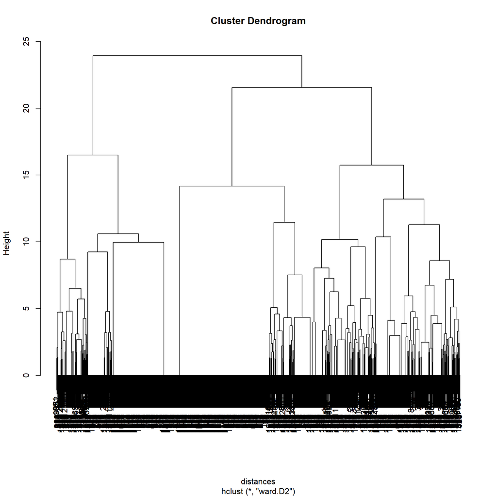

```r
clusterMovies = hclust(distances, method = "ward.D2")
plot(clusterMovies)
```

From the dendrogram, we can see that a good number to choose is 7 in the middle. Let us take a look at the dendrogram if we do divide the data into 7 clusters.

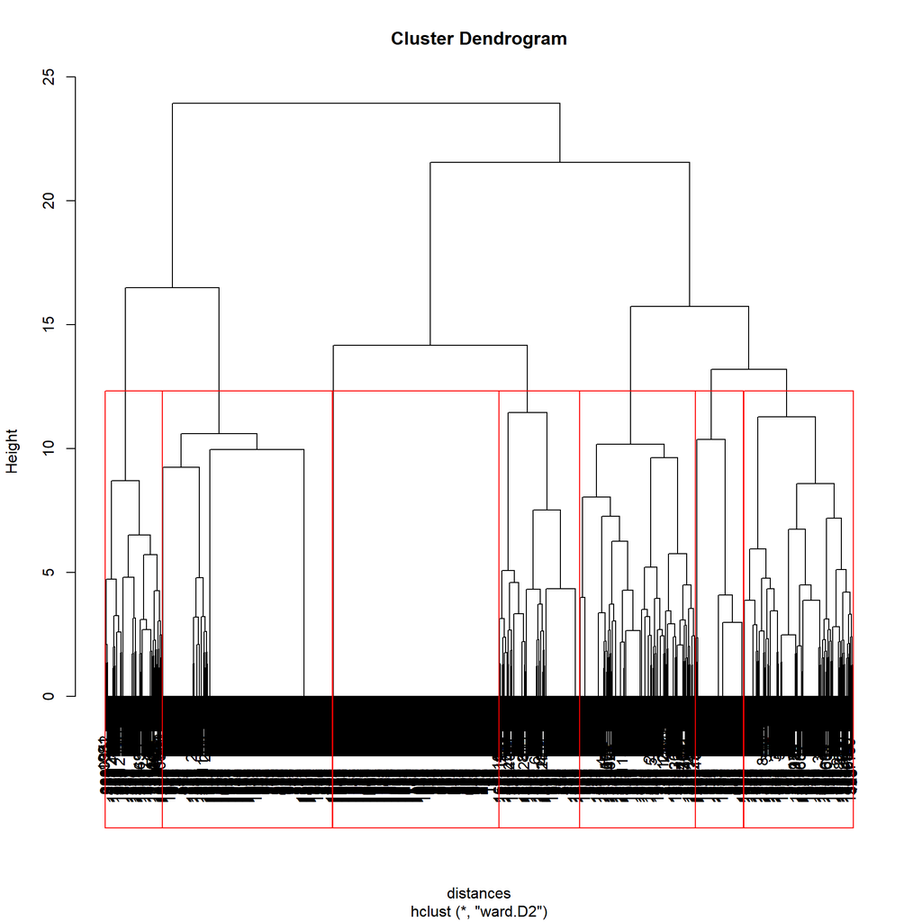

```r
plot(clusterMovies)
rect.hclust(clusterMovies, k = 7, border = "red")
```

The actual choice of number of clusters requires a lot more careful investigation and comparison. Now we just go ahead to have 7 clusters for our analysis and look at the clusters of the first 30 movies.

```r
clusterGroups = cutree(clusterMovies, k = 7)
clusterGroups[1:30]
```

```
##  1  2  3  4  5  6  7  8  9 10 11 12 13 14 15 16 17 18 19 20 21 22 23 24 25
##  1  2  3  2  3  4  2  1  4  5  3  3  6  5  4  6  3  4  4  5  6  5  3  2  6
## 26 27 28 29 30
##  6  2  2  2  4
```

Let us see how many movies are clustered in each group.

```r
table(clusterGroups)
```

```
## clusterGroups
##   1   2   3   4   5   6   7
## 127 258 244 370 179 379 107
```

We are interested in what the clusters are like. We can use the ‘tapply’ function to compute the percentage of movies in each genre and cluster.

```r
tapply(movies$Action, clusterGroups, mean)
```

```
##     1     2     3     4     5     6     7
## 0.071 0.733 0.082 0.000 0.151 0.011 0.000
```

The above code divides the data points into the 7 clusters and then computes the average value of the *Action* variable for each cluster. Remember that the *action* variable is a binary variable with value 0 or 1, so by computing the average of this variable, we are computing the percentage of movies in that cluster that belong to that genre. To see such information in a complete manner, we can use the ‘aggregate’ function.

```r
aggregate(movies[,-1], list(clusterGroups), mean)
```

| Group.1 | Unknown | Action | Adventure | Animation | Childrens | Comedy | Crime | Documentary | Drama | Fantasy | FilmNoir | Horror | Musical | Mystery | Romance | SciFi | Thriller | War | Western |
| --- | --- | --- | --- | --- | --- | --- | --- | --- | --- | --- | --- | --- | --- | --- | --- | --- | --- | --- | --- |
| 1 | 0.0000 | 0.071 | 0.3386 | 0.307 | 0.8898 | 0.35 | 0.0079 | 0.0000 | 0.157 | 0.1654 | 0.0000 | 0.000 | 0.150 | 0.0000 | 0.031 | 0.0630 | 0.0079 | 0.0000 | 0.0000 |
| 2 | 0.0000 | 0.733 | 0.3333 | 0.012 | 0.0116 | 0.13 | 0.0310 | 0.0000 | 0.147 | 0.0000 | 0.0000 | 0.062 | 0.000 | 0.0078 | 0.047 | 0.3178 | 0.2984 | 0.0388 | 0.1008 |
| 3 | 0.0082 | 0.082 | 0.0041 | 0.000 | 0.0082 | 0.11 | 0.3934 | 0.0000 | 0.373 | 0.0041 | 0.0943 | 0.057 | 0.000 | 0.2377 | 0.070 | 0.0287 | 0.6352 | 0.0000 | 0.0000 |
| 4 | 0.0000 | 0.000 | 0.0000 | 0.000 | 0.0000 | 0.00 | 0.0000 | 0.0000 | 1.000 | 0.0000 | 0.0000 | 0.000 | 0.000 | 0.0000 | 0.000 | 0.0000 | 0.0000 | 0.0000 | 0.0000 |
| 5 | 0.0000 | 0.151 | 0.0112 | 0.000 | 0.0000 | 0.13 | 0.0112 | 0.0056 | 0.642 | 0.0000 | 0.0056 | 0.011 | 0.000 | 0.0000 | 0.737 | 0.0112 | 0.0782 | 0.3352 | 0.0056 |
| 6 | 0.0000 | 0.011 | 0.0026 | 0.000 | 0.0053 | 0.96 | 0.0000 | 0.0000 | 0.195 | 0.0000 | 0.0000 | 0.000 | 0.098 | 0.0000 | 0.208 | 0.0026 | 0.0026 | 0.0026 | 0.0000 |
| 7 | 0.0000 | 0.000 | 0.0000 | 0.000 | 0.0000 | 0.10 | 0.0000 | 0.4579 | 0.075 | 0.0000 | 0.0000 | 0.542 | 0.000 | 0.0000 | 0.000 | 0.0000 | 0.0000 | 0.0000 | 0.0000 |

To make a recommendation from a specific cluster, we can take a look at the movie titles in that cluster. For example, let us look at the first ten titles in the second cluster.

```r
cluster2 = subset(movies, clusterGroups == 2)
cluster2$Title[1:10]
```

```
##  [1] GoldenEye (1995)            Get Shorty (1995)
##  [3] Twelve Monkeys (1995)       Rumble in the Bronx (1995)
##  [5] Bad Boys (1995)             Apollo 13 (1995)
##  [7] Batman Forever (1995)       Net, The (1995)
##  [9] Star Wars (1977)            Natural Born Killers (1994)
## 1664 Levels: 'Til There Was You (1997) ...
```

# 3 $k$-Means Clustering

Now let us try a different clustering technique, the $k$-means clustering algorithm. The first step in $k$-means clustering involves specifying the number of clusters, $k$. For this example, we use the result from hierarchical clustering to set $k = 7$ to compare the clustering outcomes. In practice, determining an appropriate $k$ requires more analysis, and there are various methods available to choose $k$.

```r
k = 7
```

Since $k$-means clustering algorithm starts with a random partition, let us synchronize our results by setting a common seed.

```r
set.seed(1)
```

The following code performs $k$-means clustering on our data with a maximum iteration of 1000 to stop the algorithm due to its slow convergence.

```r
clusterMoviesKM = kmeans(movies[2:20], centers = k, iter.max = 1000)
str(clusterMoviesKM)
```

```
## List of 9
##  $ cluster     : Named int [1:1664] 3 5 7 4 1 4 4 3 4 4 ...
##   ..- attr(*, "names")= chr [1:1664] "1" "2" "3" "4" ...
##  $ centers     : num [1:7, 1:19] 0 0 0 0.00234 0 ...
##   ..- attr(*, "dimnames")=List of 2
##   .. ..$ : chr [1:7] "1" "2" "3" "4" ...
##   .. ..$ : chr [1:19] "Unknown" "Action" "Adventure" "Animation" ...
##  $ totss       : num 2246
##  $ withinss    : num [1:7] 75.1 144.9 134.1 625.2 170.1 ...
##  $ tot.withinss: num 1421
##  $ betweenss   : num 824
##  $ size        : int [1:7] 84 208 115 854 145 23 235
##  $ iter        : int 3
##  $ ifault      : int 0
##  - attr(*, "class")= chr "kmeans"
```

Let us extract the cluster information from the results and store them in a new vector. We can check the clusters of the first 30 movies.

```r
clusterGroupsKM = clusterMoviesKM$cluster
clusterGroupsKM[1:30]
```

```
##  1  2  3  4  5  6  7  8  9 10 11 12 13 14 15 16 17 18 19 20 21 22 23 24 25
##  3  5  7  4  1  4  4  3  4  4  1  1  4  2  4  2  6  4  4  2  5  4  7  6  4
## 26 27 28 29 30
##  4  5  7  6  4
```

Similarly, we can check how many movies are clustered in each group by $k$-means clustering.

```r
table(clusterGroupsKM)
```

```
## clusterGroupsKM
##   1   2   3   4   5   6   7
##  84 208 115 854 145  23 235
```

We can observe that these numbers are quite different from the results by hierarchical clustering. Let us use the ‘aggregate’ function to check the cluster composition.

```r
aggregate(movies[,-1], list(clusterGroupsKM), mean)
```

| Group.1 | Unknown | Action | Adventure | Animation | Childrens | Comedy | Crime | Documentary | Drama | Fantasy | FilmNoir | Horror | Musical | Mystery | Romance | SciFi | Thriller | War | Western |
| --- | --- | --- | --- | --- | --- | --- | --- | --- | --- | --- | --- | --- | --- | --- | --- | --- | --- | --- | --- |
| 1 | 0.0000 | 0.000 | 0.000 | 0.0000 | 0.000 | 0.143 | 1 | 0.000 | 0.476 | 0.0119 | 0.119 | 0.0238 | 0.000 | 0.107 | 0.048 | 0.0119 | 0.3571 | 0.000 | 0.0000 |
| 2 | 0.0000 | 0.019 | 0.019 | 0.0000 | 0.000 | 0.447 | 0 | 0.000 | 0.433 | 0.0048 | 0.000 | 0.0048 | 0.053 | 0.019 | 1.000 | 0.0048 | 0.0288 | 0.053 | 0.0048 |
| 3 | 0.0000 | 0.035 | 0.322 | 0.2783 | 1.000 | 0.348 | 0 | 0.000 | 0.165 | 0.1217 | 0.000 | 0.0000 | 0.183 | 0.017 | 0.035 | 0.0348 | 0.0000 | 0.000 | 0.0087 |
| 4 | 0.0023 | 0.026 | 0.007 | 0.0070 | 0.000 | 0.377 | 0 | 0.059 | 0.598 | 0.0023 | 0.007 | 0.0176 | 0.023 | 0.018 | 0.000 | 0.0246 | 0.0012 | 0.049 | 0.0222 |
| 5 | 0.0000 | 0.931 | 0.524 | 0.0138 | 0.034 | 0.172 | 0 | 0.000 | 0.021 | 0.0207 | 0.000 | 0.0690 | 0.028 | 0.014 | 0.076 | 0.2966 | 0.1310 | 0.103 | 0.0414 |
| 6 | 0.0000 | 1.000 | 0.304 | 0.0000 | 0.000 | 0.174 | 1 | 0.000 | 0.304 | 0.0000 | 0.000 | 0.0435 | 0.000 | 0.043 | 0.087 | 0.0435 | 0.1739 | 0.000 | 0.0000 |
| 7 | 0.0000 | 0.260 | 0.013 | 0.0085 | 0.000 | 0.026 | 0 | 0.000 | 0.196 | 0.0043 | 0.034 | 0.2596 | 0.000 | 0.115 | 0.064 | 0.1234 | 0.8000 | 0.013 | 0.0000 |

For comparison, let us look at the first ten titles in the second cluster.

```r
cluster2KM = subset(movies, clusterGroupsKM == 2)
cluster2KM$Title[1:10]
```

```
##  [1] Postino, Il (1994)                 French Twist (Gazon maudit) (1995)
##  [3] Angels and Insects (1995)          Mad Love (1995)
##  [5] I.Q. (1994)                        Legends of the Fall (1994)
##  [7] While You Were Sleeping (1995)     Forrest Gump (1994)
##  [9] Four Weddings and a Funeral (1994) Hudsucker Proxy, The (1994)
## 1664 Levels: 'Til There Was You (1997) ...
```